# Repeated Observations

## Disclaimer

Some facts on analysis of repeated observations are prepared in this notebook.

## Classification of Repeated Observation Data

The following three classes of repeated observation data can be distinguished

1. Repeated observations in the predictors
2. Repeated observations in the response variables
3. Repeated observations in both the predictors and the responses

### Repeated Observations in Predictors

This corresponds to the dataset of blood pressure and pulse frequency. This dataset is given by

```r
s_bp_data_path <- "https://charlotte-ngs.github.io/asmasss2024/data/20240429_bp_data.csv"
df_bp <- read.table(s_bp_data_path, header = T, sep = ",")
df_bp
```

| Nr | SYS | DIA | PUL | MP_Rep | ManualPulseFreq |
| --- | --- | --- | --- | --- | --- |
| 1 | 150 | 95 | 92 | MP1 | 104 |
| 1 | 150 | 95 | 92 | MP2 | 92 |
| 1 | 150 | 95 | 92 | MP3 | 84 |
| 2 | 135 | 89 | 70 | MP1 | 72 |
| 2 | 135 | 89 | 70 | MP2 | 70 |
| 2 | 135 | 89 | 70 | MP3 | 76 |
| 3 | 121 | 85 | 69 | MP1 | 66 |
| 3 | 121 | 85 | 69 | MP2 | 72 |
| 3 | 121 | 85 | 69 | MP3 | 70 |
| 4 | 122 | 82 | 65 | MP1 | 62 |

[output cut: 23 more lines]

This data can be displayed as

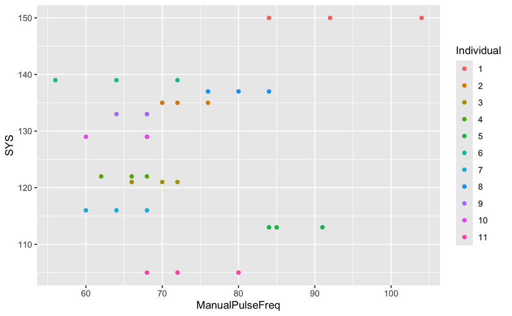

```r
p_sys_nr <- ggplot(data = df_bp,
               mapping = aes(x = ManualPulseFreq,
                             y = SYS)) +
  geom_point(aes(color = as.factor(Nr))) +
  labs(color = "Individual")
p_sys_nr
```

This type of datastructure is comparable to the example where repeated observations are used to predict the breeding value of an animal. The analysis of this type of dataset is done by fitting a linear regression model of the response on the mean of the repeated observations. Hence, we first have to compute the mean of the predictors and then fit the regression model.

```r
# compute the mean
library(dplyr)
tbl_bp_mfreq_mean <- df_bp %>%
  group_by(Nr) %>%
  summarise(mean_sys = mean(SYS),
            mean_dia = mean(DIA),
            mean_pul = mean(PUL),
            mean_mfreq = mean(ManualPulseFreq))
tbl_bp_mfreq_mean
```

| Nr | mean_sys | mean_dia | mean_pul | mean_mfreq |
| --- | --- | --- | --- | --- |
| 1 | 150 | 95 | 92 | 93.33333 |
| 2 | 135 | 89 | 70 | 72.66667 |
| 3 | 121 | 85 | 69 | 69.33333 |
| 4 | 122 | 82 | 65 | 65.33333 |
| 5 | 113 | 79 | 76 | 86.66667 |
| 6 | 139 | 83 | 64 | 64.00000 |
| 7 | 116 | 75 | 72 | 64.00000 |
| 8 | 137 | 85 | 93 | 80.00000 |
| 9 | 133 | 83 | 90 | 66.66667 |
| 10 | 129 | 83 | 65 | 65.33333 |

[output cut: 1 more lines]

The fit of the regression model is

```r
lm_msys_mfreq <- lm(mean_sys ~ mean_mfreq, data = tbl_bp_mfreq_mean)
summary(lm_msys_mfreq)
```

```
Call:
lm(formula = mean_sys ~ mean_mfreq, data = tbl_bp_mfreq_mean)

Residuals:
    Min      1Q  Median      3Q     Max
-22.459  -6.685   4.270   7.792  15.720

Coefficients:
            Estimate Std. Error t value Pr(>|t|)
(Intercept) 102.4456    31.4616   3.256   0.0099 **
mean_mfreq    0.3411     0.4286   0.796   0.4467
---
Signif. codes:  0 ‘***’ 0.001 ‘**’ 0.01 ‘*’ 0.05 ‘.’ 0.1 ‘ ’ 1

Residual standard error: 13.43 on 9 degrees of freedom
Multiple R-squared:  0.06573,   Adjusted R-squared:  -0.03808
F-statistic: 0.6332 on 1 and 9 DF,  p-value: 0.4467
```

If there are concerns about outliers in the predictors, then the `median` is more robust against outliers.

### Repeated Observations in the Response

This example corresponds to the dataset with the influence of breed on body weight observed for beef animals. The dataset is given by

```r
s_rep_path_bw_br <- "https://charlotte-ngs.github.io/asmasss2024/data/asm_bw_breed_rep_obs.csv"
df_bw_br_rep <- read.table(s_rep_path_bw_br, header = T, sep = ",")
df_bw_br_rep
```

| Animal | Body.Weight | Breed | Time |
| --- | --- | --- | --- |
| 2 | 463.0000 | Angus | first |
| 2 | 468.8940 | Angus | second |
| 2 | 467.8753 | Angus | third |
| 5 | 496.0000 | Simmental | first |
| 5 | 495.0033 | Simmental | second |
| 5 | 493.6563 | Simmental | third |
| 7 | 518.0000 | Limousin | first |
| 7 | 509.3221 | Limousin | second |
| 7 | 506.5958 | Limousin | third |
| 10 | 541.0000 | Limousin | first |

[output cut: 2 more lines]

The plot

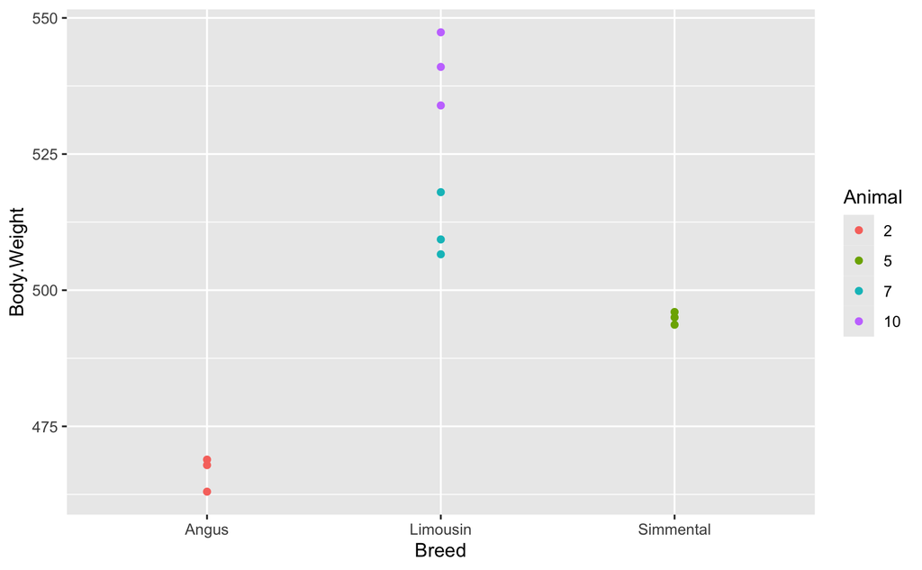

```r
library(ggplot2)
ggplot(data = df_bw_br_rep, aes(x = Breed, y = Body.Weight)) +
  geom_point(aes(color = as.factor(Animal))) +
  labs(color = "Animal")
```

This dataset is analysed with a linear model using the factor as a random effect which accounts for the variance structure

```r
library(lme4)
lmer_bw_br <- lmer(Body.Weight ~ Breed + (1 | Animal), data = df_bw_br_rep)
summary(lmer_bw_br)
```

```
Linear mixed model fit by REML ['lmerMod']
Formula: Body.Weight ~ Breed + (1 | Animal)
   Data: df_bw_br_rep

REML criterion at convergence: 61.8

Scaled residuals:
    Min      1Q  Median      3Q     Max
-1.3714 -0.5383  0.0640  0.3213  1.4305

Random effects:
 Groups   Name        Variance Std.Dev.
 Animal   (Intercept) 426.21   20.645
 Residual              22.98    4.794
Number of obs: 12, groups:  Animal, 4

Fixed effects:
               Estimate Std. Error t value
(Intercept)      466.59      20.83  22.400
BreedLimousin     59.44      25.51   2.330
BreedSimmental    28.30      29.46   0.961

Correlation of Fixed Effects:
            (Intr) BrdLms
BreedLimosn -0.816
BreedSmmntl -0.707  0.577
```

Comparing the variance part of the results of `lmer` with the results of `aov` is shown below

```r
aov_bw_br <- aov(Body.Weight ~ Breed + Error(Animal), data = df_bw_br_rep)
summary(aov_bw_br)
```

```
Error: Animal
      Df Sum Sq Mean Sq
Breed  1   8651    8651

Error: Within
          Df Sum Sq Mean Sq F value Pr(>F)
Breed      2   7.38   3.689   0.161  0.854
Residuals  8 183.84  22.980
```

### Repeated Observations in Both Predictors and Response

This corresponds to the dataset on BW and BC of beef cattle animals. An analysis of such a dataset could be done using Machine Learning techniques. Alternatively, we could also average over the BC-values and treat the data as an instance of the second type by fitting a regression of BW on mean BC.

The dataset is given by

```r
s_rep_path_bw_bc <- "https://charlotte-ngs.github.io/asmasss2024/data/asm_bw_bc_rep_obs.csv"
tbl_bw_bc_rep <- readr::read_delim(s_rep_path_bw_bc, delim = ",")
tbl_bw_bc_rep
```

| Animal | Breast Circumference | Body Weight |
| --- | --- | --- |
| 2 | 177.0000 | 463.0000 |
| 2 | 177.3129 | 468.8940 |
| 2 | 177.3292 | 467.8753 |
| 5 | 179.0000 | 496.0000 |
| 5 | 178.6501 | 495.0033 |
| 5 | 178.7485 | 493.6563 |
| 7 | 181.0000 | 518.0000 |
| 7 | 180.9819 | 509.3221 |
| 7 | 181.1467 | 506.5958 |
| 10 | 184.0000 | 541.0000 |

[output cut: 2 more lines]

The plot shows variation in both predictor and response

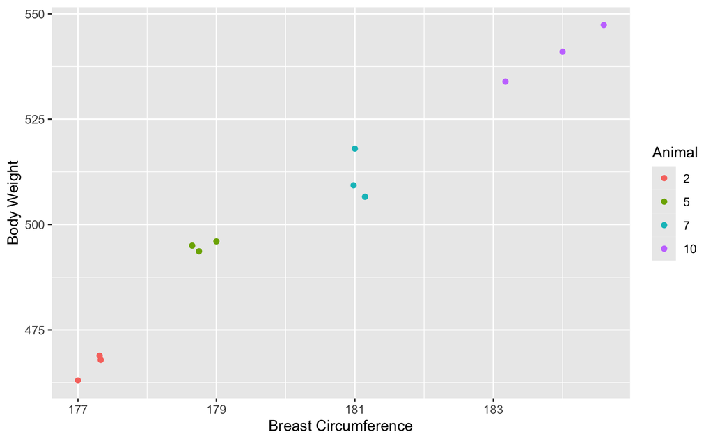

```r
library(ggplot2)
p_bw_bc_rep <- ggplot(data = tbl_bw_bc_rep,
                      mapping = aes(x = `Breast Circumference`,
                                    y = `Body Weight`)) +
  geom_point(aes(color = as.factor(Animal))) +
  labs(color = "Animal")
p_bw_bc_rep
```

A simplified analysis is to run a linear model of repeated observations of body weight on the mean of `Breast Circumference`

```r
library(dplyr)
tbl_bc_mean <- tbl_bw_bc_rep %>%
  group_by(Animal) %>%
  summarise(mean_bc = mean(`Breast Circumference`))
tbl_bc_mean
```

| Animal | mean_bc |
| --- | --- |
| 2 | 177.2140 |
| 5 | 178.7996 |
| 7 | 181.0429 |
| 10 | 183.9235 |

Join back the mean values to the original data set

```r
tbl_bw_bc_mean <- tbl_bw_bc_rep %>%
  inner_join(tbl_bc_mean, by = c("Animal" = "Animal")) %>%
  select(Animal, `Body Weight`, mean_bc)
tbl_bw_bc_mean
```

| Animal | Body Weight | mean_bc |
| --- | --- | --- |
| 2 | 463.0000 | 177.2140 |
| 2 | 468.8940 | 177.2140 |
| 2 | 467.8753 | 177.2140 |
| 5 | 496.0000 | 178.7996 |
| 5 | 495.0033 | 178.7996 |
| 5 | 493.6563 | 178.7996 |
| 7 | 518.0000 | 181.0429 |
| 7 | 509.3221 | 181.0429 |
| 7 | 506.5958 | 181.0429 |
| 10 | 541.0000 | 183.9235 |

[output cut: 2 more lines]

Fit the linear model

```r
library(lme4)
lmer_bw_bc <- lmer(`Body Weight` ~ mean_bc + (1 | Animal), data = tbl_bw_bc_mean)
summary(lmer_bw_bc)
```

```
Linear mixed model fit by REML ['lmerMod']
Formula: `Body Weight` ~ mean_bc + (1 | Animal)
   Data: tbl_bw_bc_mean

REML criterion at convergence: 69.6

Scaled residuals:
     Min       1Q   Median       3Q      Max
-1.48481 -0.56881  0.04596  0.37782  1.37516

Random effects:
 Groups   Name        Variance Std.Dev.
 Animal   (Intercept) 27.87    5.279
 Residual             22.98    4.794
Number of obs: 12, groups:  Animal, 4

Fixed effects:
             Estimate Std. Error t value
(Intercept) -1392.453    213.013  -6.537
mean_bc        10.518      1.182   8.901

Correlation of Fixed Effects:
        (Intr)
mean_bc -1.000
```

## Old Material is Below Here

The material below is kept for reference purposes.

## Data

The data we are using is on beef cattle and on blood pressure measurements.

```r
s_rep_path_bw_bc <- "https://charlotte-ngs.github.io/asmasss2024/data/asm_bw_bc_rep_obs.csv"
tbl_bw_bc_rep <- readr::read_delim(s_rep_path_bw_bc, delim = ",")
tbl_bw_bc_rep
```

| Animal | Breast Circumference | Body Weight |
| --- | --- | --- |
| 2 | 177.0000 | 463.0000 |
| 2 | 177.3129 | 468.8940 |
| 2 | 177.3292 | 467.8753 |
| 5 | 179.0000 | 496.0000 |
| 5 | 178.6501 | 495.0033 |
| 5 | 178.7485 | 493.6563 |
| 7 | 181.0000 | 518.0000 |
| 7 | 180.9819 | 509.3221 |
| 7 | 181.1467 | 506.5958 |
| 10 | 184.0000 | 541.0000 |

[output cut: 2 more lines]

The second data set is on body weight and breed, also with repeated observations.

```r
s_rep_path_bw_br <- "https://charlotte-ngs.github.io/asmasss2024/data/asm_bw_breed_rep_obs.csv"
tbl_bw_br_rep <- readr::read_delim(s_rep_path_bw_br, delim = ",")
tbl_bw_br_rep
```

| Animal | Body Weight | Breed | Time |
| --- | --- | --- | --- |
| 2 | 463.0000 | Angus | first |
| 2 | 468.8940 | Angus | second |
| 2 | 467.8753 | Angus | third |
| 5 | 496.0000 | Simmental | first |
| 5 | 495.0033 | Simmental | second |
| 5 | 493.6563 | Simmental | third |
| 7 | 518.0000 | Limousin | first |
| 7 | 509.3221 | Limousin | second |
| 7 | 506.5958 | Limousin | third |
| 10 | 541.0000 | Limousin | first |

[output cut: 2 more lines]

## Plots

The plots of the data already show certain patterns which are important to be considered in any statistical analysis.

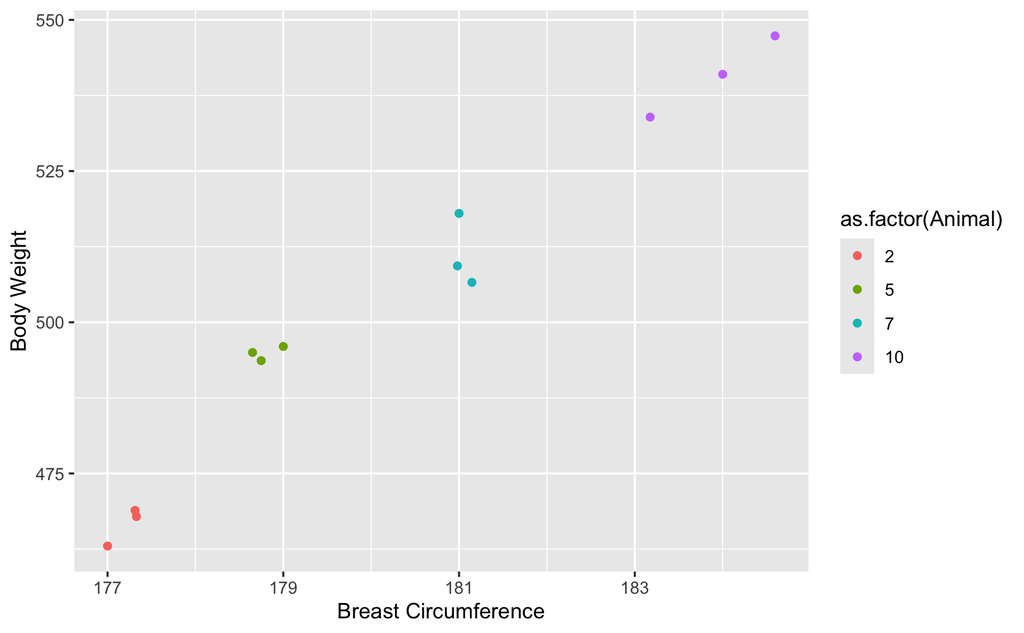

```r
library(ggplot2)
p_bw_bc_rep <- ggplot(data = tbl_bw_bc_rep,
                      mapping = aes(x = `Breast Circumference`,
                                    y = `Body Weight`)) +
  geom_point(aes(color = as.factor(Animal)))
p_bw_bc_rep
```

A similar plot with `Breed`

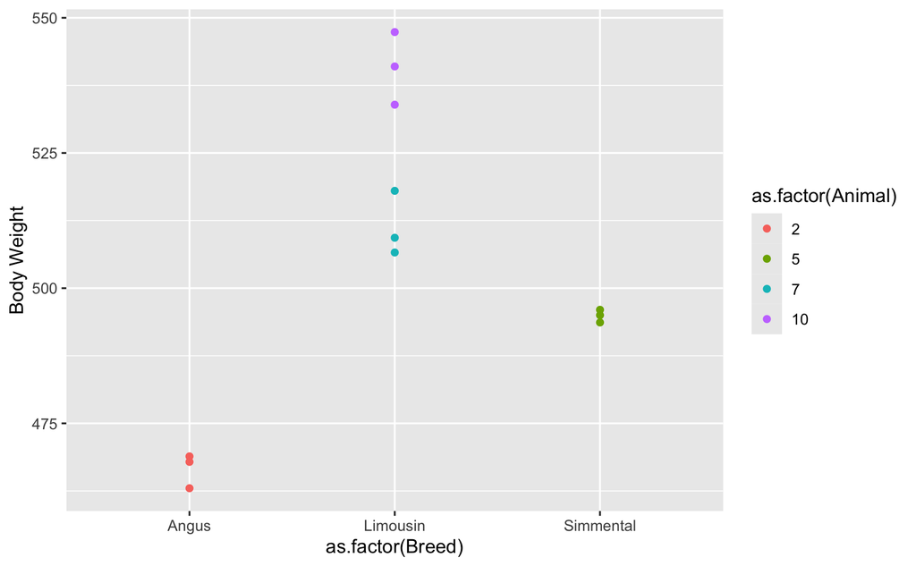

```r
library(ggplot2)
p_bw_br_rep <- ggplot(data = tbl_bw_br_rep,
                      mapping = aes(x = as.factor(Breed),
                                    y = `Body Weight`)) +
  geom_point(aes(color = as.factor(Animal)))
p_bw_br_rep
```

### Statistical Model

Analysis according to `ChatGPT`

```r
# Install and load necessary packages
install.packages("lme4")
library(lme4)

# Assuming your dataset is called 'data' with columns 'animal_id', 'body_weight', and 'breast_circumference'
# Fit a linear mixed-effects model
model <- lmer(body_weight ~ breast_circumference + (1 | animal_id), data = data)
summary(model)
```

Applying the above for the BW-BC dataset we get

```r
if (!is.element("lme4", installed.packages())) install.packages("lme4")
library(lme4)

lmer_bw_bc <- lmer(`Body Weight` ~ `Breast Circumference` + (1 | Animal) , data = tbl_bw_bc_rep)
summary(lmer_bw_bc)
```

```
Linear mixed model fit by REML ['lmerMod']
Formula: `Body Weight` ~ `Breast Circumference` + (1 | Animal)
   Data: tbl_bw_bc_rep

REML criterion at convergence: 64.5

Scaled residuals:
     Min       1Q   Median       3Q      Max
-1.67538 -0.23499 -0.08804  0.19610  2.04354

Random effects:
 Groups   Name        Variance Std.Dev.
 Animal   (Intercept) 30.02    5.479
 Residual             12.07    3.474
Number of obs: 12, groups:  Animal, 4

Fixed effects:
                        Estimate Std. Error t value
(Intercept)            -1357.727    196.186  -6.921
`Breast Circumference`    10.325      1.088   9.488

Correlation of Fixed Effects:
            (Intr)
`BCrcmfrnc` -1.000
```

Is the fixed part of the regression also obtained with fitting a regression through the mean observations

```r
library(dplyr)
tbl_bw_bc_mean <- tbl_bw_bc_rep %>%
  group_by(Animal) %>%
  summarise(mean_bw = mean(`Body Weight`),
            mean_bc = mean(`Breast Circumference`))
tbl_bw_bc_mean
```

| Animal | mean_bw | mean_bc |
| --- | --- | --- |
| 2 | 466.5898 | 177.2140 |
| 5 | 494.8866 | 178.7996 |
| 7 | 511.3059 | 181.0429 |
| 10 | 540.7632 | 183.9235 |

Fit the regression model

```r
lm_bw_bc_mean <- lm(mean_bw ~ mean_bc, data = tbl_bw_bc_mean)
summary(lm_bw_bc_mean)
```

```
Call:
lm(formula = mean_bw ~ mean_bc, data = tbl_bw_bc_mean)

Residuals:
      1       2       3       4
-4.9165  6.7035 -0.4726 -1.3144

Coefficients:
             Estimate Std. Error t value Pr(>|t|)
(Intercept) -1392.453    213.013  -6.537   0.0226 *
mean_bc        10.518      1.182   8.901   0.0124 *
---
Signif. codes:  0 ‘***’ 0.001 ‘**’ 0.01 ‘*’ 0.05 ‘.’ 0.1 ‘ ’ 1

Residual standard error: 5.961 on 2 degrees of freedom
Multiple R-squared:  0.9754,    Adjusted R-squared:  0.9631
F-statistic: 79.23 on 1 and 2 DF,  p-value: 0.01239
```

## Data on Blood Pressure

When asking `ChatGPT` the following question

> “How to analyse a dataset with single observations in the response variable and repeated observations in the predictor variable using a regression model in R”

The following answer is provided in summary, the data has to be analysed using

```r
install.packages("lme4")
library(lme4)

# Assuming your response variable is called 'response' and predictor variable is called 'predictor'
# 'group' represents the grouping variable (e.g., individual ID or time point)
# 'data' is your dataset

model <- lmer(response ~ predictor + (1 | group), data = data)

# results
summary(model)

# diagnostics
plot(model)
```

The blood pressure data is given as

```r
s_bp_data_path <- "https://charlotte-ngs.github.io/asmasss2024/data/20240429_bp_data.csv"
df_bp <- read.table(s_bp_data_path, header = T, sep = ",")
df_bp
```

| Nr | SYS | DIA | PUL | MP_Rep | ManualPulseFreq |
| --- | --- | --- | --- | --- | --- |
| 1 | 150 | 95 | 92 | MP1 | 104 |
| 1 | 150 | 95 | 92 | MP2 | 92 |
| 1 | 150 | 95 | 92 | MP3 | 84 |
| 2 | 135 | 89 | 70 | MP1 | 72 |
| 2 | 135 | 89 | 70 | MP2 | 70 |
| 2 | 135 | 89 | 70 | MP3 | 76 |
| 3 | 121 | 85 | 69 | MP1 | 66 |
| 3 | 121 | 85 | 69 | MP2 | 72 |
| 3 | 121 | 85 | 69 | MP3 | 70 |
| 4 | 122 | 82 | 65 | MP1 | 62 |

[output cut: 23 more lines]

This data can be used to fit a regression of either `SYS`, `DIA` or `PUL` on the average of the repeated observations of `ManualPulseFreq`. To do this, we have to create a dataset with the means of `ManualPulseFreq`

```r
library(dplyr)
tbl_bp_mean <- df_bp %>%
  group_by(Nr) %>%
  summarise(mean_man_freq = mean(ManualPulseFreq),
            mean_sys = mean(SYS),
            mean_dia = mean(DIA),
            mean_pul = mean(PUL))
tbl_bp_mean
```

| Nr | mean_man_freq | mean_sys | mean_dia | mean_pul |
| --- | --- | --- | --- | --- |
| 1 | 93.33333 | 150 | 95 | 92 |
| 2 | 72.66667 | 135 | 89 | 70 |
| 3 | 69.33333 | 121 | 85 | 69 |
| 4 | 65.33333 | 122 | 82 | 65 |
| 5 | 86.66667 | 113 | 79 | 76 |
| 6 | 64.00000 | 139 | 83 | 64 |
| 7 | 64.00000 | 116 | 75 | 72 |
| 8 | 80.00000 | 137 | 85 | 93 |
| 9 | 66.66667 | 133 | 83 | 90 |
| 10 | 65.33333 | 129 | 83 | 65 |

[output cut: 1 more lines]

The computation of the regression coefficient has to be adapted to be able to account for the variability of the repeated observations of the predictors.